# EDS 222: Week 10: In-class Lab

{ANSWER KEY}

2022-11-28

**Note:** This lab is built from an exercise provided by Soren Wilke (original post has been taken down).

# Section 0: Getting set up

1. Store this file in a *Labs/* folder where you store all your lab materials for EDS 222.
2. Install the following new (new to EDS 222) packages:[^1]
3. Load the following packages:

```r
library(tidyverse)
library(sf)
library(sp)
library(raster)
library(gstat)
library(automap)
library(patchwork)
library(viridis)
options(scipen = 999) # disable scientific notation

# For labs, we want to see all our code
knitr::opts_chunk$set(echo = TRUE)
```

4. Set your working directory

```r
rootdir <- ("~/Dropbox/Teaching/UCSB/EDS_222/EDS222_data")
```

5. Generate this function. We will use it for plotting later – it is not necessary at all, it will just make things look pretty.

```r
plot_my_gstat_output <- function(raster_object, object_name){

  df <- rasterToPoints(raster_object) %>% as_tibble()
  colnames(df) <- c("X", "Y", "Z")

  ggplot(df, aes(x = X, y = Y, fill = Z)) +
    geom_raster() +
    ggtitle(label = object_name) +
    scale_fill_viridis(option = "B", limits = c(48, 101)) +
    theme_void() +
    theme(
      plot.title = element_text(hjust = 0.5)
    )
}
```

# Section 1: Spatial point data

The data for this tutorial is a xyz-file giving us the height of the groundwater table in a part of the German state of North Rhine-Westphalia in 1988.

We have measures of the groundwater level in 1988 at a limited number of monitoring wells, but our goal is ultimately to estimate the groundwater level throughout the surrounding region. This is often the case when studying groundwater, which is generally measured with a small set of monitoring wells.

Here let’s just take a look at our input data:

```r
#wellobs <- readRDS("week-ten-data.RDS") #simple way, put in same directory

wellobs <- readRDS(file.path(rootdir, "labs", "10-week-ten", "week-ten-data.RDS"))
head(wellobs)
```

```
## # A tibble: 6 × 3
##        X       Y     Z
##    <dbl>   <dbl> <dbl>
## 1 407640 5732860  81.2
## 2 411040 5729860  93.8
## 3 411540 5735460  65.5
## 4 409840 5732460  87.6
## 5 404940 5733860  74.1
## 6 407840 5727160  66.2
```

3. Use `ggplot` to plot the locations of the monitoring wells as points, with color indicating depth of the well. I’m going to use `viridis` because it’s aesthetically nice and `theme_classic()` to clean up the plot a bit.

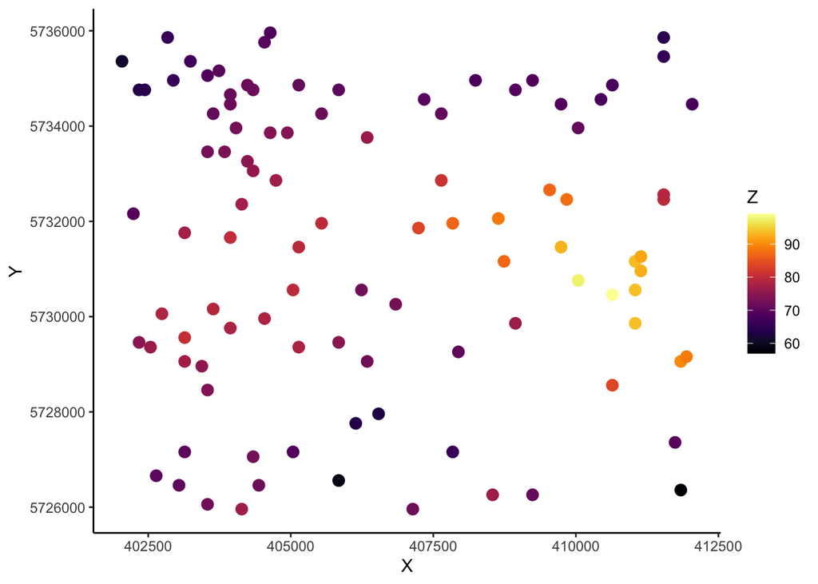

```r
wellobs %>%
  ggplot(
  mapping = aes(x = X, y = Y, color = Z)) +
  geom_point(size = 3) +
  scale_color_viridis(option = "B") + #optional
  theme_classic() #optional
```

4. What do you notice about the spatial correlation in this plot? Does it seem reasonable to attempt spatial interpolation in this setting?

# Section 2: Creating a Variogram

As we discussed in class, kriging relies on an estimated or prescribed variogram, which is essentially a function describing the relationship between distance and covariance in “Z” in your point data. Here we are going to create an empirical variogram, which gives us the distribution of spatial dependencies observed in the data.

1. First, we need to convert the data from a `data.frame` to an `sf` object, because that is usually the easiest way to save and work with spatial data. Use the `st_as_sf` function to do this, noting that the [raw data](http://www.govdata.de/dl-de/by-2-0) come in the EPSG 25832 projection.

When you do this, make sure to save the coordinates “X” and “Y” in the resulting `sf` object so that you can use them later if needed (some forms of kriging rely on them directly).

```r
wellobs_sf <- st_as_sf(wellobs, coords = c("X", "Y"), crs = 25832) %>%
  cbind(st_coordinates(.))
```

2. Second, use the function `autofitVariogram` from the `automap` package to compute semivariances as a function of distance and to fit a variogram model through those points. Recall from class that you can choose the type of variogram model you want to fit to the data, such as spherical or Gaussian. However, here we will let `autofitVariogram` choose the model that best fits the data for us.

The first argument of `autofitVariogram` is the variogram formula defining the response variable we’re interested in and any possible regressors which determine the mean. Here, we will assume we are only using our monitoring wells to interpolate, so we have no other regressors to include in our estimate of the mean. Therefore, use `Z~1` as the formula. The second argument is our data – annoyingly, `automap` only plays nicely with `sp` objects instead of `sf` objects, so we’ll have to transform our `sf` into an `sp` within this operation.

Save the column `var_model` from the output; lots of other things are also stored that we don’t want to worry about.

```r
v_mod_full <- automap::autofitVariogram(Z~1, as(wellobs_sf, "Spatial"))

v_mod <- v_mod_full$var_model
head(v_mod)
```

```
##   model    psill    range kappa
## 1   Nug   0.0000    0.000     0
## 2   Ste 155.5775 4858.866     5
```

3. Plot this variogram model using `plot()` and passing the full model as an argument. Does it seem to fit the data well?

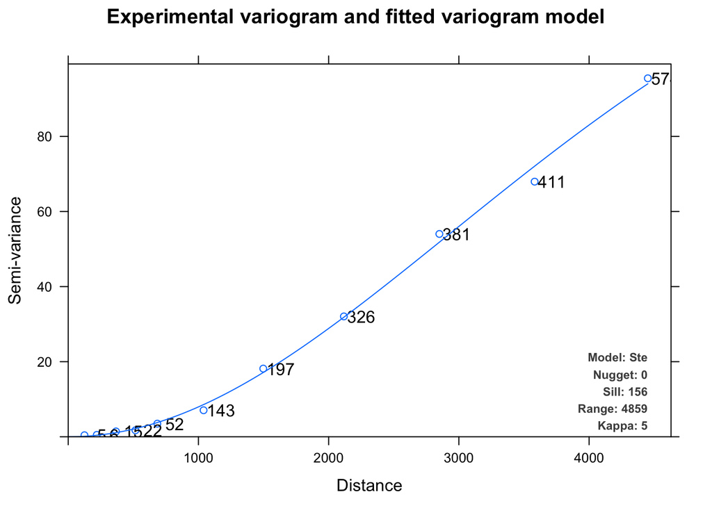

```r
plot(v_mod_full)
```

```r
# Note: text next to dots is the number of pairs used to estimate the semi variance!
```

# Section 3: Define a target grid

In order to interpolate we need a target grid with a target set of coordinates (“X”, “Y”) for which the modeled variable (“Z”) to be interpolated. This means we come up with an empty grid or raster. This holds true for kriging with `gstat`, too, except everything is a little bit more complicated, because we need to do it in `sp`.

1. Define a grid based on the bounding box of our observations. Use a 100 unit pixel size and set `what = "centers"` to center the X-Y coordinates on the middle of each grid cell.

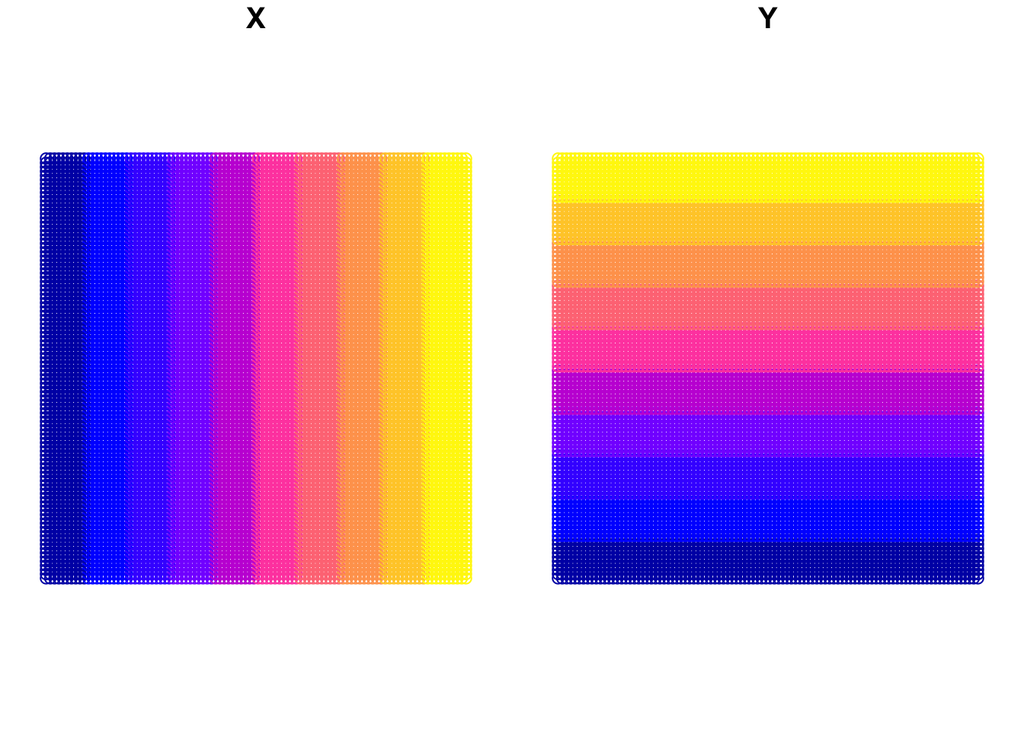

```r
grd_100_sf <- wellobs_sf %>%
  st_bbox() %>% # gets the bbox of our observations
  st_as_sfc() %>% # make the bbox an sfc object
  st_make_grid( # make the grid
  cellsize = c(100, 100), # 100m pixel size
  what = "centers"
  ) %>%
  st_as_sf() %>% # get back to sf object from sfc
  cbind(., st_coordinates(.)) # ensure you keep tracking your X-Y coordinates

# Make sure you can interpret these figures -- why do these two figures together show an empty X-Y grid?
plot(grd_100_sf)
```

2. Make the grid work for gstat by converting it to `sp`, telling `R` and `sp` that this object *is* gridded, then finally convert to `SpatialPixels`. Yes, this is annoying. No, I don’t know a better way than `gstat` to do kriging! Additional tutorial [here](https://mgimond.github.io/Spatial/interpolation-in-r.html), using similar approaches.

```r
grd_100_sp <- as(grd_100_sf, "Spatial") # converting to {sp} format
gridded(grd_100_sp) <- TRUE             # informing the object that it is a grid
grd_100_sp <- as(grd_100_sp, "SpatialPixels") # specifying what kind of grid
```

# Section 4: Ordinary Kriging

Kriging comes in several flavors, as discussed in class. We will here only focus on Ordinary Kriging, but other types are feasible in `gstat`.

Ordinary Kriging assumes that the mean in your target grid is constant and but not known to you.

In `gstat`, the main way to differentiate between different kinds of kriging (or any of the implemented algorithms) is controlled by the formula supplied. We have already seen that syntax when fitting the variogram – we use `Z~1` to indicate Ordinary Kriging.

1. Use the `krige()` function from `gstat` to generate a full set of predictions of groundwater levels at all locations across the region.

```r
OK <- krige(
  Z~1,                       # Z is our variable and "~1" means "depends on mean"
  as(wellobs_sf, "Spatial"), # input data in {sp} format
  grd_100_sp,                # locations to interpolate at
  model = v_mod           # the variogram model fitted above
  )
```

```
## [using ordinary kriging]
```

```r
# Check out the dimensions of the "OK" object. Does this make sense?
dim(OK)
```

```
## [1] 10000     2
```

```r
# krige() will save the predicted value in OK$var1.pred, and the estimated variance in OK$var1.var. Do these values look like they make sense to you?
head(OK$var1.pred)
```

```
## [1] 89.37888 87.64188 85.90488 84.18593 82.50566 80.88680
```

```r
head(OK$var1.var)
```

```
## [1] 0.39341507 0.30126034 0.22985291 0.17448007 0.13141863 0.09781477
```

2. Take a look at your predictions (*always* a good idea) by plotting the raw monitoring data next to a raster of your kriging-based predictions. For the kriging output, use the `plot_my_gstat_output()` function you generated earlier. Pass `OK` into this function as a raster.

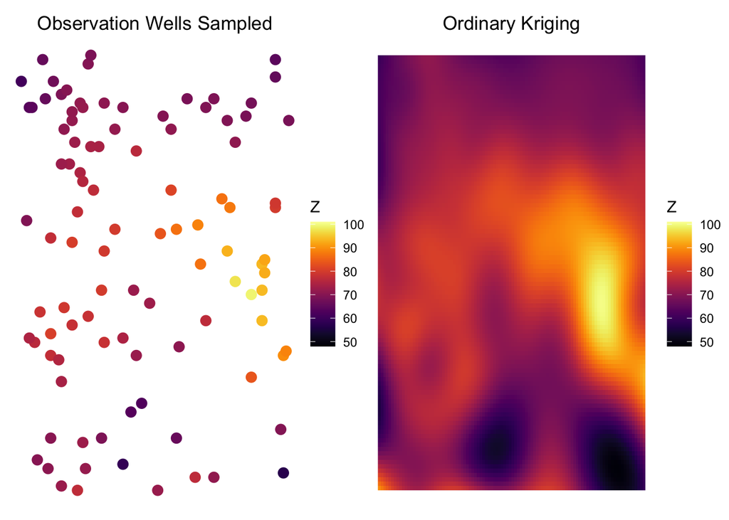

```r
# Raw wells
p_raw = ggplot(
  data = wellobs,
  mapping = aes(x = X, y = Y, color = Z)
) +
  geom_point(size = 3) +
  scale_color_viridis(option = "B",  limits = c(48, 101)) +
  ggtitle(label = "Observation Wells Sampled") +
  theme_void() +
    theme(
      plot.title = element_text(hjust = 0.5)
    )

# Ordinary Kriging output
p_kriging = plot_my_gstat_output(raster(OK), "Ordinary Kriging") # a simple `plot(raster(OK))` also works just fine

p_raw + p_kriging
```

Based on this visual, how well do you think ordinary kriging worked? What other methods would you try next?

[^1]: Hint: for `gstat` you do *not* want to install from source.